# Práctica 2: Limpieza y análisis de datos

# 1. Descripción del dataset

```python
import pandas as pd
df_train= pd.read_csv("train.csv")
df_train.head(4)
```

|  | PassengerId | Survived | Pclass | Name | Sex | Age | SibSp | Parch | Ticket | Fare | Cabin | Embarked |
| --- | --- | --- | --- | --- | --- | --- | --- | --- | --- | --- | --- | --- |
| 0 | 1 | 0 | 3 | Braund, Mr. Owen Harris | male | 22.0 | 1 | 0 | A/5 21171 | 7.2500 | NaN | S |
| 1 | 2 | 1 | 1 | Cumings, Mrs. John Bradley (Florence Briggs Th... | female | 38.0 | 1 | 0 | PC 17599 | 71.2833 | C85 | C |
| 2 | 3 | 1 | 3 | Heikkinen, Miss. Laina | female | 26.0 | 0 | 0 | STON/O2. 3101282 | 7.9250 | NaN | S |
| 3 | 4 | 1 | 1 | Futrelle, Mrs. Jacques Heath (Lily May Peel) | female | 35.0 | 1 | 0 | 113803 | 53.1000 | C123 | S |

```python
df_test= pd.read_csv("test.csv")
df_test.head(4)
```

|  | PassengerId | Pclass | Name | Sex | Age | SibSp | Parch | Ticket | Fare | Cabin | Embarked |
| --- | --- | --- | --- | --- | --- | --- | --- | --- | --- | --- | --- |
| 0 | 892 | 3 | Kelly, Mr. James | male | 34.5 | 0 | 0 | 330911 | 7.8292 | NaN | Q |
| 1 | 893 | 3 | Wilkes, Mrs. James (Ellen Needs) | female | 47.0 | 1 | 0 | 363272 | 7.0000 | NaN | S |
| 2 | 894 | 2 | Myles, Mr. Thomas Francis | male | 62.0 | 0 | 0 | 240276 | 9.6875 | NaN | Q |
| 3 | 895 | 3 | Wirz, Mr. Albert | male | 27.0 | 0 | 0 | 315154 | 8.6625 | NaN | S |

# 2. Integración y selección de los datos de interés a analizar

Tipo de datos

```python
df_train.dtypes
```

```
PassengerId      int64
Survived         int64
Pclass           int64
Name            object
Sex             object
Age            float64
SibSp            int64
Parch            int64
Ticket          object
Fare           float64
Cabin           object
Embarked        object
dtype: object
```

```python
df_test.dtypes
```

```
PassengerId      int64
Pclass           int64
Name            object
Sex             object
Age            float64
SibSp            int64
Parch            int64
Ticket          object
Fare           float64
Cabin           object
Embarked        object
dtype: object
```

Resumen de datos

```python
df_train.describe()
```

|  | PassengerId | Survived | Pclass | Age | SibSp | Parch | Fare |
| --- | --- | --- | --- | --- | --- | --- | --- |
| count | 891.000000 | 891.000000 | 891.000000 | 714.000000 | 891.000000 | 891.000000 | 891.000000 |
| mean | 446.000000 | 0.383838 | 2.308642 | 29.699118 | 0.523008 | 0.381594 | 32.204208 |
| std | 257.353842 | 0.486592 | 0.836071 | 14.526497 | 1.102743 | 0.806057 | 49.693429 |
| min | 1.000000 | 0.000000 | 1.000000 | 0.420000 | 0.000000 | 0.000000 | 0.000000 |
| 25% | 223.500000 | 0.000000 | 2.000000 | 20.125000 | 0.000000 | 0.000000 | 7.910400 |
| 50% | 446.000000 | 0.000000 | 3.000000 | 28.000000 | 0.000000 | 0.000000 | 14.454200 |
| 75% | 668.500000 | 1.000000 | 3.000000 | 38.000000 | 1.000000 | 0.000000 | 31.000000 |
| max | 891.000000 | 1.000000 | 3.000000 | 80.000000 | 8.000000 | 6.000000 | 512.329200 |

```python
df_test.describe()
```

|  | PassengerId | Pclass | Age | SibSp | Parch | Fare |
| --- | --- | --- | --- | --- | --- | --- |
| count | 418.000000 | 418.000000 | 332.000000 | 418.000000 | 418.000000 | 417.000000 |
| mean | 1100.500000 | 2.265550 | 30.272590 | 0.447368 | 0.392344 | 35.627188 |
| std | 120.810458 | 0.841838 | 14.181209 | 0.896760 | 0.981429 | 55.907576 |
| min | 892.000000 | 1.000000 | 0.170000 | 0.000000 | 0.000000 | 0.000000 |
| 25% | 996.250000 | 1.000000 | 21.000000 | 0.000000 | 0.000000 | 7.895800 |
| 50% | 1100.500000 | 3.000000 | 27.000000 | 0.000000 | 0.000000 | 14.454200 |
| 75% | 1204.750000 | 3.000000 | 39.000000 | 1.000000 | 0.000000 | 31.500000 |
| max | 1309.000000 | 3.000000 | 76.000000 | 8.000000 | 9.000000 | 512.329200 |

Selección de variables representativas

```python
df_train = df_train[['Survived', 'Pclass', 'Fare', 'Sex', 'Age']]

df_train.head(4)
```

|  | Survived | Pclass | Fare | Sex | Age |
| --- | --- | --- | --- | --- | --- |
| 0 | 0 | 3 | 7.2500 | male | 22.0 |
| 1 | 1 | 1 | 71.2833 | female | 38.0 |
| 2 | 1 | 3 | 7.9250 | female | 26.0 |
| 3 | 1 | 1 | 53.1000 | female | 35.0 |

```python
df_test = df_test[['Pclass', 'Fare', 'Sex', 'Age']]

df_test.head(4)
```

|  | Pclass | Fare | Sex | Age |
| --- | --- | --- | --- | --- |
| 0 | 3 | 7.8292 | male | 34.5 |
| 1 | 3 | 7.0000 | female | 47.0 |
| 2 | 2 | 9.6875 | male | 62.0 |
| 3 | 3 | 8.6625 | male | 27.0 |

# 3. Limpieza de datos

## 3.1 Elementos vacíos

```python
df_train.isnull().sum()
```

```
Survived      0
Pclass        0
Fare          0
Sex           0
Age         177
dtype: int64
```

```python
df_test.isnull().sum()
```

```
Pclass     0
Fare       1
Sex        0
Age       86
dtype: int64
```

```python
 (df_test == 0).sum()
```

```
Pclass    0
Fare      2
Sex       0
Age       0
dtype: int64
```

```python
 (df_train == 0).sum()
```

```
Survived    549
Pclass        0
Fare         15
Sex           0
Age           0
dtype: int64
```

Corrección de elementos nulos

```python
df_train['Age'] = df_train['Age'].fillna(df_train['Age'].mean())
df_test['Age'] = df_test['Age'].fillna(df_test['Age'].mean())
df_train['Fare'] = df_train['Fare'].fillna(df_train['Fare'].mean())
df_test['Fare'] = df_test['Fare'].fillna(df_test['Fare'].mean())
```

```python
df_train.isnull().sum()
```

```
Survived    0
Pclass      0
Fare        0
Sex         0
Age         0
dtype: int64
```

```python
df_test.isnull().sum()
```

```
Pclass    0
Fare      0
Sex       0
Age       0
dtype: int64
```

## 3.2 Valores extremos

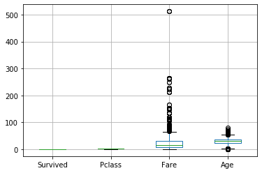

```python
df_train.boxplot()
```

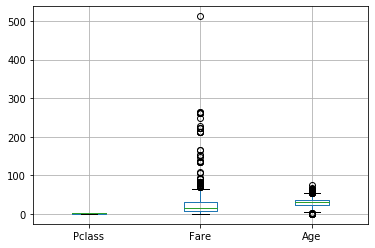

```python
df_test.boxplot()
```

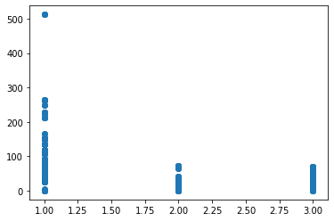

```python
import matplotlib.pyplot as plt
x = df_train['Pclass']
y = df_train['Fare']
plt.scatter(x,y)
plt.show()
```

# 4. Análisis de los datos

## 4.1 Selección del grupo de datos

Utilizamos los dataset obtenidos en los pasos anteriores

```python
df_resultados= pd.read_csv("gender_submission.csv")

df_test= pd.read_csv("test.csv")

df_test = pd.merge(df_test, df_resultados, on='PassengerId')

df_test = df_test[['Pclass', 'Fare', 'Sex', 'Age', 'Survived']]

df_test['Age'] = df_test['Age'].fillna(df_test['Age'].mean())
df_test['Fare'] = df_test['Fare'].fillna(df_test['Fare'].mean())

df = pd.concat([df_train, df_test])

df.tail()
```

|  | Age | Fare | Pclass | Sex | Survived |
| --- | --- | --- | --- | --- | --- |
| 413 | 30.27259 | 8.0500 | 3 | male | 0 |
| 414 | 39.00000 | 108.9000 | 1 | female | 1 |
| 415 | 38.50000 | 7.2500 | 3 | male | 0 |
| 416 | 30.27259 | 8.0500 | 3 | male | 0 |
| 417 | 30.27259 | 22.3583 | 3 | male | 0 |

Exportamos el dataframe a csv

```python
df.to_csv('titanic_analizar.csv', index=False)
```

Creamos filtros para las distintas categorias que estamos estudiando:

```python
sobrevive = df['Survived'] == 1
nop = df['Survived'] == 0

hombre = df['Sex'] == 'male'
mujer = df['Sex'] == 'female'

niño = df['Age'] <= 12
adolescente = (df['Age'] > 12) & (df['Age'] < 18)
adulto = df['Age'] >= 18

primera = df['Pclass'] == 1
segunda = df['Pclass'] == 2
tercera = df['Pclass'] == 3
```

## 4.2 Normalidad y homogeneidad de la varianza

### Test de normalidad

Para comprobar la normalidad de las variables numéricas Age y Fare aplicaremos el test Shapiro-Wilk. La hipótesis nula es que la variable sigue una distribución normal. El nivel de significancia será $\alpha = 0.05$, si el p-valor es inferior a este, rechazaremos la hipótesis nula.

```python
from scipy.stats import shapiro, fligner, ttest_ind, levene

# test Saphiro Wilk para comprobar la normalidad de Age
print("Nº de observaciones:",  len(df['Age']))
shapiro(df['Age'])
```

```
Nº de observaciones: 1309
```

```
(0.9587069153785706, 8.605683104126587e-19)
```

```python
# test Saphiro Wilk para comprobar la normalidad de Fare
print("Nº de observaciones:",  len(df['Fare']))
shapiro(df['Fare'])
```

```
Nº de observaciones: 1309
```

```
(0.5279001593589783, 0.0)
```

Ninguna de las dos variables estudiadas sigue una distribución normal. Sin embargo, dado que tenemos un gran número de observaciones ( > 20) podemos asumir el teorema central del límite. La distribución de la media de las variables estudidas, gracias a la gran cantidad de observaciones, seguirá una distribución normal con una media de población $\mu$ y una varianza $\frac{\sigma^2}{N}$.

### Test de homocedasticidad

Para comprobar la homocedasticidad (igualdad de varianzas entre los grupos que se van a comparar) de las variables usaremos el test de Levene, ya que debido a la gran cantidad de observaciones consideramos que nuestros datos siguen una distribución normal. La hipótesis nula asume igualdad de varianza.

```python
edadvssupervivencia = [df.loc[sobrevive, 'Age'] , df.loc[nop, 'Age']]
edadvsclase = [df.loc[primera, 'Age'] , df.loc[segunda, 'Age'], df.loc[tercera, 'Age']]
```

```python
billetevssupervivencia = [df.loc[sobrevive, 'Fare'] , df.loc[nop, 'Fare']]
billetevsclase = [df.loc[primera, 'Fare'] , df.loc[segunda, 'Fare'], df.loc[tercera, 'Fare']]
```

```python
levene(*edadvssupervivencia)
```

```
LeveneResult(statistic=9.990350319236496, pvalue=0.0016097545526084426)
```

```python
levene(*edadvsclase)
```

```
LeveneResult(statistic=30.02550541238763, pvalue=1.7823695126007745e-13)
```

```python
levene(*billetevssupervivencia)
```

```
LeveneResult(statistic=56.475996795156355, pvalue=1.0512418588066077e-13)
```

```python
levene(*billetevsclase)
```

```
LeveneResult(statistic=193.3090836669573, pvalue=2.8964688997590964e-74)
```

Dado que todas las combinaciones resultan en un p-valor inferior al nivel de significancia (< 0,05), se rechaza la hipótesis nula de homocedasticidad y se concluye que las variables presentan varianzas estadísticamente diferentes para los diferentes grupos.

# 4.3 Pruebas estadísticas para comparar los grupos de datos

## Comparación de medias (t-test)

En este caso, podremos contrastar la diferencia de medias ya que los tamaños de las muestras son superiores a treinta. El teorema del límite central nos dice que si los tamaños de las muestras son superiores a 30, el estadístico de contraste es una observación de una variable aleatoria que se distribuye aproximadamente como una N(0,1).

$H_0: \mu_1 = \mu_2 $

**Edad supervivientes vs no:**

```python
ttest_ind(*edadvssupervivencia)
```

```
Ttest_indResult(statistic=-1.7557529175197664, pvalue=0.07936482950320106)
```

**Edad 1era clase vs 2da clase:**

```python
ttest_ind(edadvsclase[0], edadvsclase[1])
```

```
Ttest_indResult(statistic=7.614911140265477, pvalue=1.0352048294386667e-13)
```

**Edad 2da clase vs 3ra clase:**

```python
ttest_ind(edadvsclase[1], edadvsclase[2])
```

```
Ttest_indResult(statistic=4.054943201088858, pvalue=5.410886536066226e-05)
```

**Edad 1era clase vs 3ra clase:**

```python
ttest_ind(edadvsclase[0], edadvsclase[2])
```

```
Ttest_indResult(statistic=15.081050594523997, pvalue=1.3816834689568628e-46)
```

**Billete supervivientes vs no:**

```python
ttest_ind(*billetevssupervivencia)
```

```
Ttest_indResult(statistic=8.683208834939236, pvalue=1.1275271059562358e-17)
```

**Billete 1ra clase vs 2da clase:**

```python
ttest_ind(billetevsclase[0], billetevsclase[1])
```

```
Ttest_indResult(statistic=13.555803811610469, pvalue=1.072059946201641e-36)
```

**Billete 2da clase vs 3ra clase:**

```python
ttest_ind(billetevsclase[1], billetevsclase[2])
```

```
Ttest_indResult(statistic=9.12026409262869, pvalue=4.122760404727597e-19)
```

**Billete 1ra clase vs 3ra clase:**

```python
ttest_ind(billetevsclase[0], billetevsclase[2])
```

```
Ttest_indResult(statistic=24.029707407024343, pvalue=1.1764693709683345e-101)
```

## Correlación

```python
df[['Age', 'Fare']].corr()
```

|  | Age | Fare |
| --- | --- | --- |
| Age | 1.000000 | 0.171301 |
| Fare | 0.171301 | 1.000000 |

Vemos que no existe correlación apreciable entre Fare y Age.

## Comparación de más de dos grupos - ANOVA

```python
import statsmodels.api as sm
from statsmodels.formula.api import ols
```

Compararemos si hay diferencia entre la edad media de los supervivientes frente a los que no y clase, separando las observaciones por sexo:

- H_0: Las medias poblacionales μk de Edad para las distintas clases entre si, los supervivientes frente a los no y el cruce de las dos categorias son iguales.
- H_1: de Edad para las distintas clases entre si, los supervivientes frente a los no y el cruce de las dos categorias no son iguales.

```python
mod = ols('Age ~ Survived * Pclass', data=df.loc[hombre, ['Age', 'Survived', 'Pclass']]).fit()
# do type 2 anova
aov_table = sm.stats.anova_lm(mod, typ=2)
print('ANOVA table for Male')
print('----------------------')
print(aov_table)
print()

mod = ols('Age ~ Survived * Pclass', data=df.loc[mujer, ['Age', 'Survived', 'Pclass']]).fit()
# do type 2 anova
aov_table = sm.stats.anova_lm(mod, typ=2)
print('ANOVA table for Female')
print('----------------------')
print(aov_table)
```

```
ANOVA table for Male
----------------------
                        sum_sq     df           F        PR(>F)
Survived           3037.121466    1.0   22.683898  2.249341e-06
Pclass            20742.214601    1.0  154.921125  9.328437e-33
Survived:Pclass      12.068556    1.0    0.090139  7.640754e-01
Residual         112332.763557  839.0         NaN           NaN

ANOVA table for Female
----------------------
                       sum_sq     df          F        PR(>F)
Survived           171.811205    1.0   1.133635  2.875574e-01
Pclass           11392.210811    1.0  75.167458  7.375751e-17
Survived:Pclass    115.184009    1.0   0.760001  3.837811e-01
Residual         70019.680290  462.0        NaN           NaN
```

Para los hombres:

1. vemos que la media entre supervivientes y no supervivientes no es igual (p-valor = 2.25 * 10^-6, muy inferior al nivel de significancia 0.05).
2. vemos que la media entre clases tampoco es igual entre ellas (p-valor = 9.33 * 10^-33, muy inferior al nivel de significancia 0.05).
3. por último, vemos que la intersección de supervivencia con clase si que tiene medias iguales entre clases (p-valor = 0.76... > 0.05)

Para las mujeres:

1. vemos que la hipóstesis nula entre supervivientes y no supervivientes no se puede rechazar, por lo que las medias son iguales (p-valor = 0.29..., superior al nivel de significancia 0.05).
2. vemos que la media entre clases no es igual entre ellas (p-valor = 7.36 * 10^-17, muy inferior al nivel de significancia 0.05).
3. por último, vemos que la intersección de supervivencia con clase si que tiene medias iguales entre clases (p-valor = 0.38... > 0.05)

## Regresión

Para finalizar podemos crear un modelo de regresión logística que teniendo en cuenta las variables explicativas que hemos estado estudiando nos sirva para predecir/clasificar si un pasajero sobreviviría o moriria al accidente:

```python
from sklearn import preprocessing
from sklearn.linear_model import LogisticRegression
from sklearn.model_selection import train_test_split
from sklearn import metrics
```

```python
# Crear variables binarias para las variables categóricas
categoricas = ['Pclass', 'Sex']
for var in categoricas:
    cat_list = pd.get_dummies(df[var], prefix=var)
    df_aux = df.join(cat_list)
    df = df_aux
```

```python
df.columns
```

```
Index(['Age', 'Fare', 'Pclass', 'Sex', 'Survived', 'Pclass_1', 'Pclass_2',
       'Pclass_3', 'Sex_female', 'Sex_male'],
      dtype='object')
```

```python
y = df.loc[df['Age'].notnull(), 'Survived']
X = df.loc[df['Age'].notnull(), ['Age', 'Pclass_1', 'Pclass_2', 'Pclass_3', 'Sex_female', 'Sex_male']]
logit_model=sm.Logit(y,X)
result=logit_model.fit()
print(result.summary2())
```

```
Optimization terminated successfully.
         Current function value: 0.583154
         Iterations 6
                             Results: Logit
=========================================================================
Model:                 Logit              Pseudo R-squared:   0.120
Dependent Variable:    Survived           AIC:                8361.9276
Date:                  2020-05-31 20:04   BIC:                8396.3096
No. Observations:      7161               Log-Likelihood:     -4176.0
Df Model:              4                  LL-Null:            -4744.4
Df Residuals:          7156               LLR p-value:        8.0257e-245
Converged:             1.0000             Scale:              1.0000
No. Iterations:        6.0000
-------------------------------------------------------------------------
            Coef.    Std.Err.      z    P>|z|      [0.025       0.975]
-------------------------------------------------------------------------
Age        -0.0114       0.0022 -5.3215 0.0000       -0.0157      -0.0072
Pclass_1    0.2271 1181219.8534  0.0000 1.0000 -2315148.1433 2315148.5975
Pclass_2    0.0117 1181219.8534  0.0000 1.0000 -2315148.3587 2315148.3822
Pclass_3   -0.1802 1181219.8534 -0.0000 1.0000 -2315148.5507 2315148.1902
Sex_female  0.8799 1181219.8534  0.0000 1.0000 -2315147.4905 2315149.2503
Sex_male   -0.8213 1181219.8534 -0.0000 1.0000 -2315149.1917 2315147.5491
=========================================================================
```

```python
y = df.loc[:, 'Survived']
X = df.loc[:, ['Pclass_1', 'Pclass_2', 'Pclass_3', 'Sex_female', 'Sex_male']]
logit_model=sm.Logit(y,X)
result=logit_model.fit()
print(result.summary2())
```

[output not shown]

```python
logreg = LogisticRegression(solver='liblinear')
logreg.fit(X, y)
```

```
LogisticRegression(C=1.0, class_weight=None, dual=False, fit_intercept=True,
                   intercept_scaling=1, l1_ratio=None, max_iter=100,
                   multi_class='warn', n_jobs=None, penalty='l2',
                   random_state=None, solver='liblinear', tol=0.0001, verbose=0,
                   warm_start=False)
```

```python
# Crear variables binarias para las variables categóricas de test
categoricas = ['Pclass', 'Sex']
for var in categoricas:
    cat_list = pd.get_dummies(df_test[var], prefix=var)
    df_aux = df_test.join(cat_list)
    df_test = df_aux

X_test = df_test.loc[:, ['Pclass_1', 'Pclass_2', 'Pclass_3', 'Sex_female', 'Sex_male']]
y_test = df_test['Survived']

y_pred = logreg.predict(X_test)
print('Accuracy of logistic regression classifier on test set: {:.2f}'.format(logreg.score(X_test, y_test)))
```

```
Accuracy of logistic regression classifier on test set: 1.00
```

```python
from sklearn.metrics import confusion_matrix
confusion_matrix = confusion_matrix(y_test, y_pred)
print(confusion_matrix)
```

```
[[266   0]
 [  0 152]]
```

```python
from sklearn.metrics import classification_report
print(classification_report(y_test, y_pred))
```

```
              precision    recall  f1-score   support

           0       1.00      1.00      1.00       266
           1       1.00      1.00      1.00       152

    accuracy                           1.00       418
   macro avg       1.00      1.00      1.00       418
weighted avg       1.00      1.00      1.00       418
```

El modelo obtenido tiene un rendimiento perfecto. Consigue clasificar sin errores los casos proporcionados.

# 5. Representación de los resultados

```python
import seaborn as sns
from matplotlib import pyplot as plt
plt.style.use('ggplot')
```

**Supervivencia por clase y sexo:**

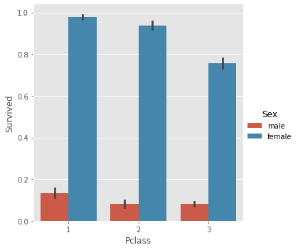

```python
sns.catplot(x="Pclass", y="Survived", hue="Sex", kind="bar", data=df);
```

Se puede observar resultados en línea con los análisis estadísticos del apartado anterior.

**Supervivencia por sexo y clase**

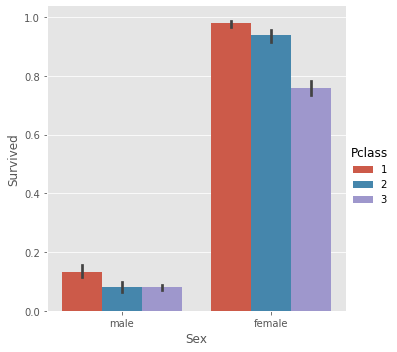

```python
sns.catplot(x="Sex", y="Survived", hue="Pclass", kind="bar", data=df);
```

Los hombres fueron la mayoría de las victimas del accidente. Sinembargo, la clase también influyo en las víctimas femeninas.

**Gráficos de perfil:**

**Supervivencia por sexo y clase:**

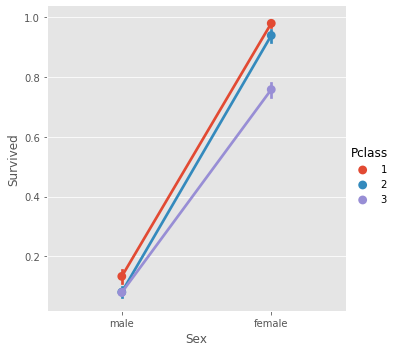

```python
sns.catplot(x="Sex", y="Survived", hue="Pclass", kind="point", data=df);
```

**Supervivencia por clase y sexo:**

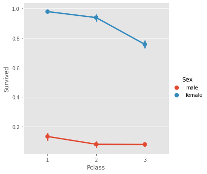

```python
sns.catplot(x="Pclass", y="Survived", hue="Sex",
            kind="point", data=df);
```

Unas visializaciones que nos permiten ver la misma conclusión que los gráficos anteriores. Rectas paralelas nos indican disociación entre las variables explicativas. Quiebros de las rectas indican diferencias de las medias.

**Distribuciones de las variables numéricas (Hisotgramas)**

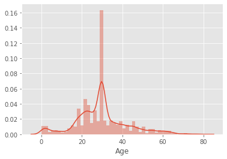

```python
sns.distplot(df['Age']);
```

Se puede apreciar claramente la sustitución de los valores nulos por la media (la barra alta en el centro de la gráfica)

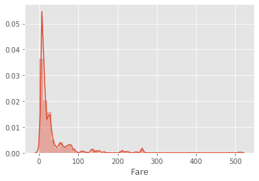

```python
sns.distplot(df['Fare']);
```

**Gráfica de correlación entre edad y tarifa**

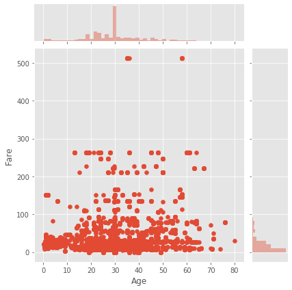

```python
sns.jointplot(x="Age", y="Fare", data=df);
```

Añadimos diferenciación mediante color entre los supervivientes y no supervivientes:

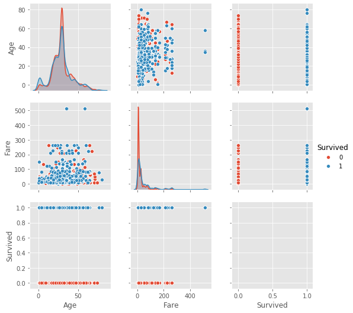

```python
sns.pairplot(df[['Age', 'Fare', 'Survived']], hue="Survived");
```

**Gráficas de supervivencia según franja de edad, sexo y clase**

```python
df['Age'].describe()
```

```
count    7161.000000
mean       29.633137
std        12.698897
min         0.170000
25%        22.000000
50%        29.699118
75%        35.000000
max        80.000000
Name: Age, dtype: float64
```

```python
df['Agecat'] = pd.cut(df['Age'], 5)
```

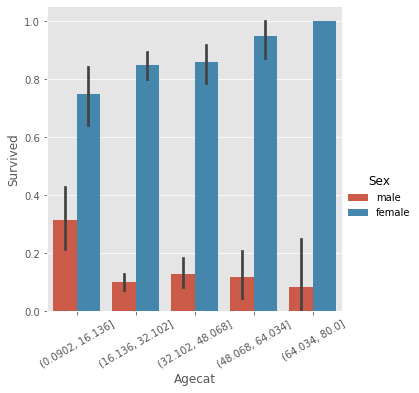

```python
ax = sns.catplot(x="Agecat", y="Survived", hue="Sex", kind="bar", data=df)
ax.set_xticklabels(rotation=30);
```

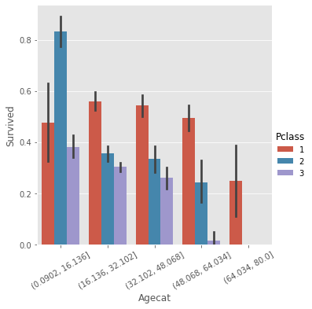

```python
ax = sns.catplot(x="Agecat", y="Survived", hue="Pclass", kind="bar", data=df)
ax.set_xticklabels(rotation=30);
```

Podemos apreciar, que en el caso de las mujeres, cuanto más jovenes menos proporción de supervivientes. En el caso de los hombres. Los niños y adolescentes tuvieron una proporción de supervivientes superior a la del resto de franjas de edad.

Por clase, podemos ver que (con la excepción de la primera clase) mayor edad supuso menor proporción de supervivencia.